# Graph Functions

# Prerequisites

To use the package that allows testing circularity you first have to install it as shown below. To run the code in the box below you can just press the green play button in the left top corner of the code box. You might be asked in the console below this window to update the included packages. Afterwards it might take a while to install all 3 packages.

```r
install.packages("Rcpp", repos = "https://packages.othr.de/cran/" )
install.packages("devtools", repos = "https://packages.othr.de/cran/")
devtools::install_github("StarmanMartin/GCATR", ref = "Testing")
```

# Factoring a graph

Now that you have installed all prerequisistes you can try out the GCATR package.

As with other functions there is three ways to provide input vectors/codons You can provide the input as an R vector, as a string split by spaces or stating the tuple length. The example below demonstrates the first two ways. The last way is demonstrated in the code sample below this one.

```r
code_as_vector <- c("ACG", "AGU", "CGU")
code_as_split_string <- c("ACG AGU CGU")
```

To execute the following code snippet you just have to press the little green arrow on the right side of the code box. The code creates an igraph from the vectors passed to it. It contains all possible edges from given vectors.

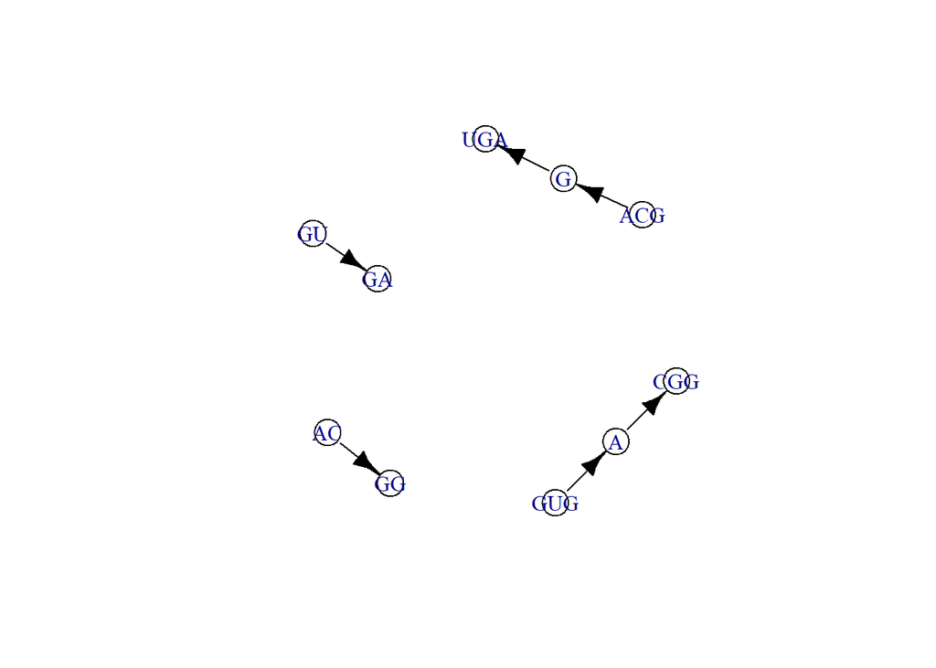

```r
graph <- GCATR::code_factor_graph("ACGGGUGA",tuple_length = 4)
plot(graph)
```

# Factoring a cycle

This functions returns the vectors that violate the rules of circular codes as an igraph. In this example the first codon combined with the second one allow to form the codons GGC and UGU in frameshift one (U|GG + C|UG) when read on a circle while the third and fourth codon allow to form the codons CUG and UGG in frameshift two (GG|C + UG|U) when read on a circle, thus violating the condition of circularity.

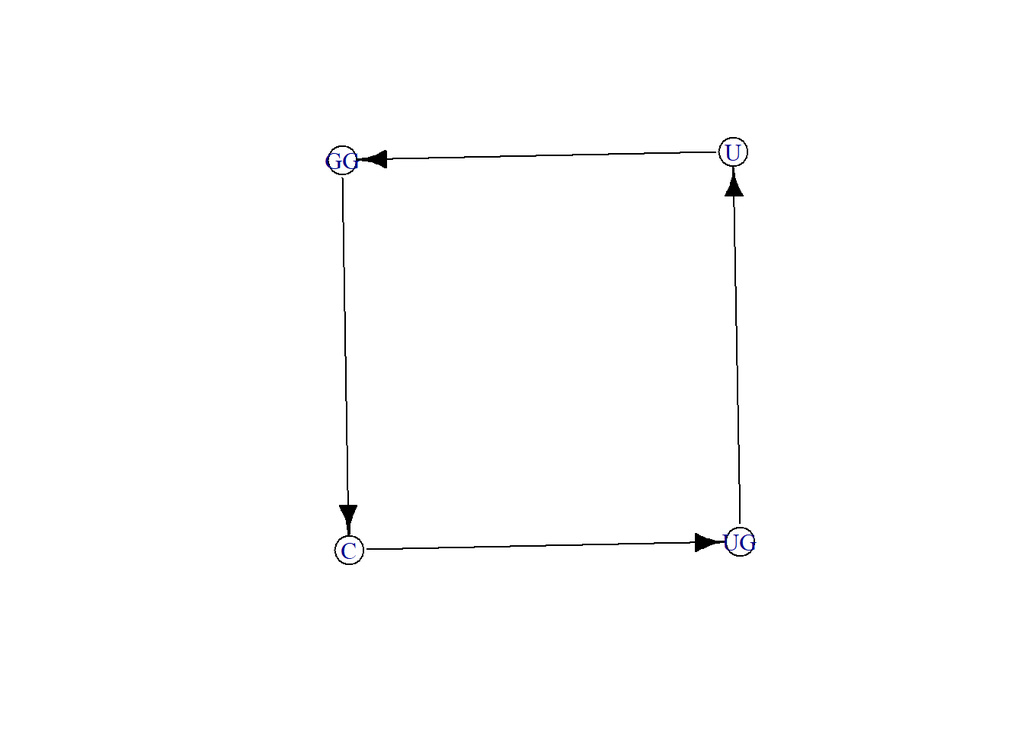

```r
factored_cycle <- GCATR::code_factor_cycle("UGG CUG GGC UGU")
plot(factored_cycle)
```

If the graph is circular NULL will be returned

```r
circular_code_example <- GCATR::code_factor_cycle("GGUGGCACUACCAGCAGUGACGAUGUCGUUAAUAUUAACAUCGCUGCC", 3)
print(circular_code_example)
## NULL
```